# Machine Learning Project

Angus Macdonald

12/10/2019

This project serves as the final project for the Coursera Practical Machine Learning Course.

## Background

This project seeks to predict the manner in which the users of the fitness device did the exercise. Devices such as *Jawbone Up*, *Nike FuelBand*, and *FitBit* are able to collect vast amounts of data about the way in which people perform exercise. Using this data, enthusiasts are trying to predict (originally) how much exercise they did, while now we can predict how well we did the exercise.

# Intro

Using machine learning techniques, this project builds a machine learning model, cross validation and the choices that led to the final prediction. This prediction was done by training a large dataset and then testing these methods on the 20 different test cases.

## The Data

The data used in this proejct comes from Ugulino, W.; Cardador, D.; Vega, K.; Velloso, E.; Milidiu, R.; Fuks, H. Wearable Computing: Accelerometers’ Data Classification of Body Postures and Movements”

This includes two datasets, a training set and a testing set.

## Data Processing

The data is loaded and processed to remove any fields that contain no/missing data as well as any other data that is not useful in predicting our model.

```r
training_set <- read.csv("Data/pml-training.csv")
validation_set <- read.csv("Data/pml-testing.csv")
```

The following data contains fields that are irrelevant to the model so they are removed.

```r
KeepThrow <- colSums(is.na(training_set) |training_set=="")
Observ <- which(KeepThrow == 0)
training_set <- training_set[, Observ]
validation_set <- validation_set[, Observ]
training_set <- training_set[, -c(1:7)]
validation_set <- validation_set[, -c(1:7)]
```

Because we want to save our validation set for the very last test we do, we shall split the training set into two separate datasets.

```r
set.seed(1903)
inTrain <- createDataPartition(training_set$classe,
                               p = 0.7, list = FALSE)
training <- training_set[inTrain, ]
testing <- training_set[-inTrain, ]
```

The data are now ready to begin using different models.

## Modelling

*Classification Trees* or simply *predicting with trees* is a process where the data are split iteratively into groups where the homogeneity is evaluated within each group. Each observation is then placed into its most commonly occuring class of training observations.

## Model 1: Classification Trees

The first model is fit on the training data using the [rpart](https://www.r-bloggers.com/trees-with-the-rpart-package/) command. Before we train the model we specify the number of cross validations to perform. Empirically the magic numebr is 10. THe reason why is beyond the scope of this project but we will attempt to keep this theory in mind.

```r
rcontrol <- rpart.control(xval = 10)
modelFit_1 <- rpart(classe ~ ., data = training, method = "class", control = rcontrol)
modelFit_1
```

[output not shown]

The data can be seen, along with the associated splits:

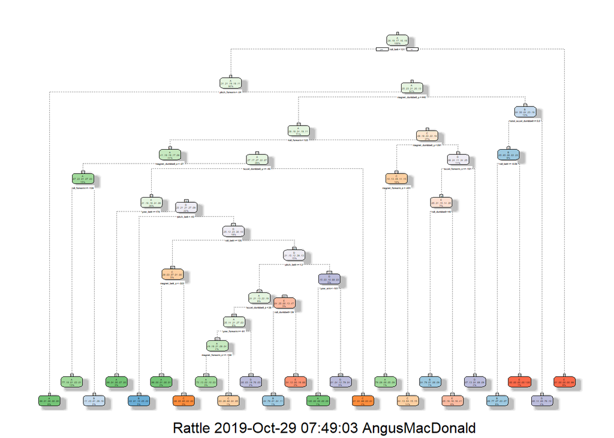

```r
fancyRpartPlot(modelFit_1)
```

The model must now be validated against the testing set. This is stored in the variable *pred_model1*. Thereafter, the data are inserted into a decision matrix.

```r
pred_model1 <- predict(modelFit_1, testing, type = "class")
confmatrix_model1 <- confusionMatrix(pred_model1, testing$classe)
confmatrix_model1
```

```
## Confusion Matrix and Statistics
##
##           Reference
## Prediction    A    B    C    D    E
##          A 1552  171   18   56   15
##          B   38  648   56   74  100
##          C   46  153  825  140  130
##          D   17   91   62  617   60
##          E   21   76   65   77  777
##
## Overall Statistics
##
##                Accuracy : 0.7509
##                  95% CI : (0.7396, 0.7619)
##     No Information Rate : 0.2845
##     P-Value [Acc > NIR] : < 2.2e-16
##
##                   Kappa : 0.6841
##
##  Mcnemar's Test P-Value : < 2.2e-16
##
## Statistics by Class:
##
##                      Class: A Class: B Class: C Class: D Class: E
## Sensitivity            0.9271   0.5689   0.8041   0.6400   0.7181
## Specificity            0.9383   0.9435   0.9035   0.9533   0.9502
## Pos Pred Value         0.8565   0.7074   0.6376   0.7285   0.7648
## Neg Pred Value         0.9700   0.9012   0.9562   0.9311   0.9374
## Prevalence             0.2845   0.1935   0.1743   0.1638   0.1839
## Detection Rate         0.2637   0.1101   0.1402   0.1048   0.1320
## Detection Prevalence   0.3079   0.1556   0.2199   0.1439   0.1726
## Balanced Accuracy      0.9327   0.7562   0.8538   0.7967   0.8342
```

## Model 2: Random Forests

Normally when performing prediction, it is best to set the k folds for cross validation equal to 10. The reason why cross validation with 10 folds is used is that there is evidence that suggests that there is little added benefit form using more than 10 folds. However, with *Random Forests* there is no need to perform cross validation to get unbiased estimates of the test set.

That being said we can run the model.

```r
modelFit_2 <- randomForest(classe~., data = training)
```

We can then have a look at the results as well as the confusion matrix for the trained model.

```r
print(modelFit_2)
confusionMatrix(modelFit_2$y, training$classe)
```

[output not shown]

We can also have a look at the effect that the number of trees have on the error rate.

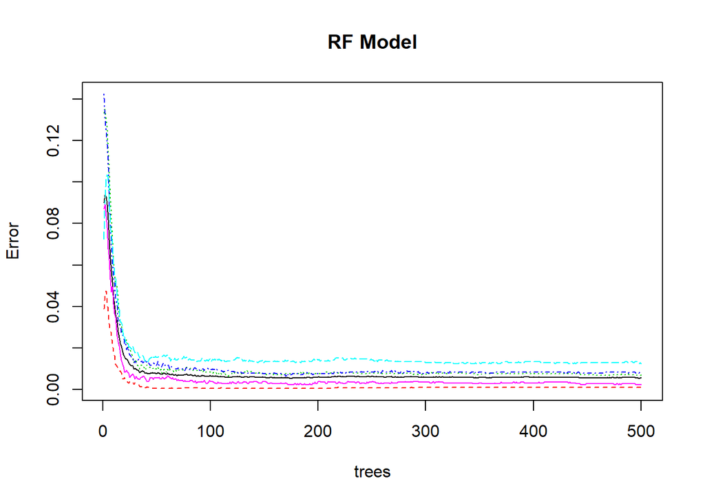

```r
plot(modelFit_2, main = "RF Model")
```

```r
predict2 <- predict(modelFit_2, testing)
confusionMatrix(predict2, testing$classe)
```

```
## Confusion Matrix and Statistics
##
##           Reference
## Prediction    A    B    C    D    E
##          A 1674    6    0    0    0
##          B    0 1131    6    0    0
##          C    0    2 1019    4    0
##          D    0    0    1  959    2
##          E    0    0    0    1 1080
##
## Overall Statistics
##
##                Accuracy : 0.9963
##                  95% CI : (0.9943, 0.9977)
##     No Information Rate : 0.2845
##     P-Value [Acc > NIR] : < 2.2e-16
##
##                   Kappa : 0.9953
##
##  Mcnemar's Test P-Value : NA
##
## Statistics by Class:
##
##                      Class: A Class: B Class: C Class: D Class: E
## Sensitivity            1.0000   0.9930   0.9932   0.9948   0.9982
## Specificity            0.9986   0.9987   0.9988   0.9994   0.9998
## Pos Pred Value         0.9964   0.9947   0.9941   0.9969   0.9991
## Neg Pred Value         1.0000   0.9983   0.9986   0.9990   0.9996
## Prevalence             0.2845   0.1935   0.1743   0.1638   0.1839
## Detection Rate         0.2845   0.1922   0.1732   0.1630   0.1835
## Detection Prevalence   0.2855   0.1932   0.1742   0.1635   0.1837
## Balanced Accuracy      0.9993   0.9959   0.9960   0.9971   0.9990
```

# Results

## Errors

The *Classification Trees* model performed moderately in terms of Sensitivity, Specificity, and Positive and Negative predictive values. However, not all classes of our predictor were consistently predicted. This is in contrast to the *Random Forests* model where all 5 classes were predicted with a high degree of accuracy among all error types.

## Model Selection

```r
predict_fin <- predict(modelFit_2, validation_set, type = "class")
print(predict_fin)
```

```
##  1  2  3  4  5  6  7  8  9 10 11 12 13 14 15 16 17 18 19 20
##  B  A  B  A  A  E  D  B  A  A  B  C  B  A  E  E  A  B  B  B
## Levels: A B C D E
```

This is what we will use to answer the project quiz.